# Kernel

Julia Deptulska

2024-11-10

# Analiza opisowa

Jednym ze sposobów zrozumienia, jak działa rząd miasta, jest spojrzenie na to, kogo zatrudnia i jak jego pracownicy są wynagradzani. Dane te zawierają nazwiska, nazwę stanowiska i wynagrodzenie pracowników miasta San Francisco w ujęciu rocznym od 2011 do 2014 roku.

Oto kilka pomysłów na eksplorację danych:

- Jak zmieniały się wynagrodzenia w czasie między różnymi grupami ludzi?
- Jak płaca podstawowa, wynagrodzenie za nadgodziny i świadczenia są rozdzielane pomiędzy różne grupy?
- Czy w tym zestawie danych istnieją dowody na dyskryminację płacową ze względu na płeć?
- Jak przydzielany jest budżet w zależności od grupy i zakresu obowiązków?

```r
# wymiary ramki:
dim(salaries)
```

```
## [1] 148654     13
```

```r
# nazwy kolumn:
names(salaries)
```

```
##  [1] "Id"               "EmployeeName"     "JobTitle"         "BasePay"
##  [5] "OvertimePay"      "OtherPay"         "Benefits"         "TotalPay"
##  [9] "TotalPayBenefits" "Year"             "Notes"            "Agency"
## [13] "Status"
```

## Histogramy

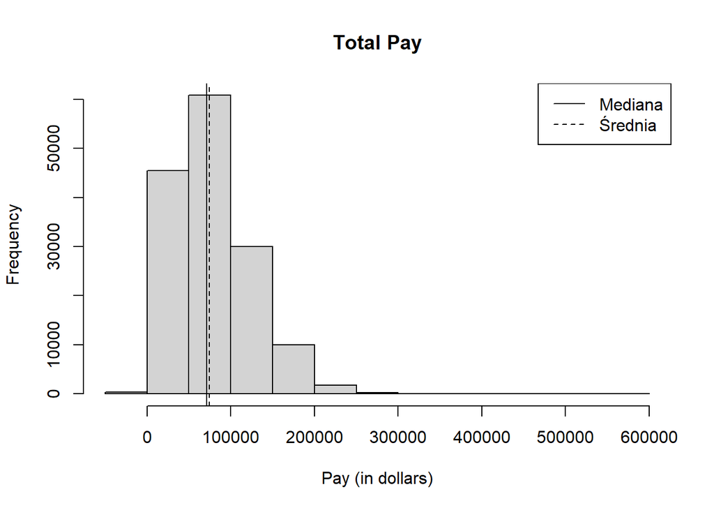

```r
hist(salaries$TotalPay,main="Total Pay", xlab="Pay (in dollars)")
abline(v = mean(salaries$TotalPay),lty="dashed")
abline(v = median(salaries$TotalPay))
legend("topright", legend=c("Mediana","Średnia"),lty=c("solid","dashed"))
```

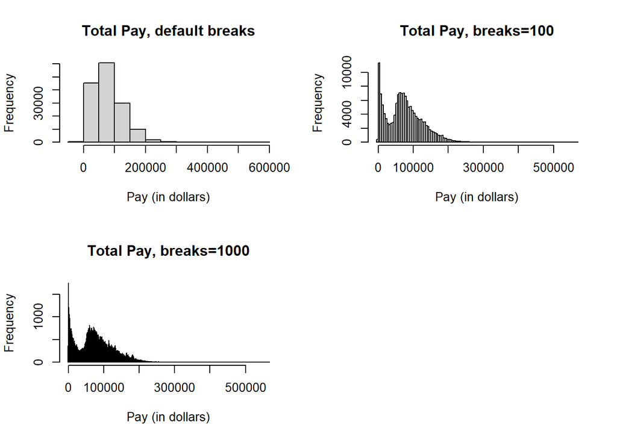

```r
par(mfrow=c(2,2))
hist(salaries$TotalPay,main="Total Pay, default breaks", xlab="Pay (in dollars)")
hist(salaries$TotalPay,main="Total Pay, breaks=100", xlab="Pay (in dollars)", breaks=100)
hist(salaries$TotalPay,main="Total Pay, breaks=1000", xlab="Pay (in dollars)",breaks=1000)
```

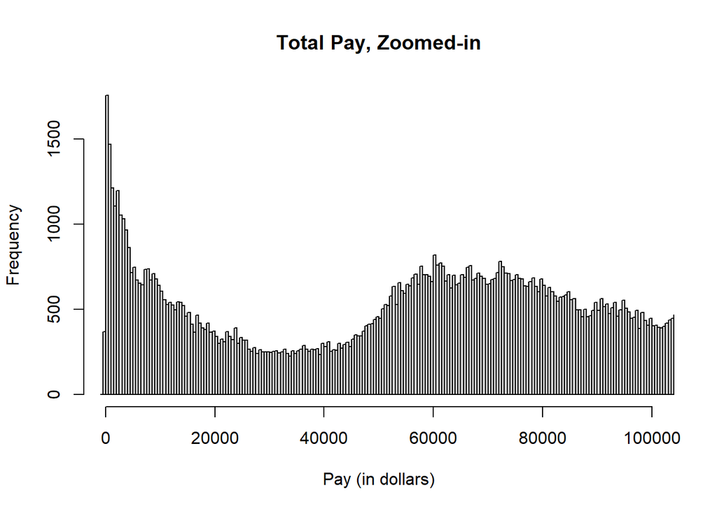

```r
hist(salaries$TotalPay,main="Total Pay, Zoomed-in", xlab="Pay (in dollars)", xlim=c(0,1e5), breaks=1000)
```

```r
salaries2 <- subset(salaries, JobTitle=="Firefighter" & Status=="FT")
dim(salaries2)
```

```
## [1] 738  13
```

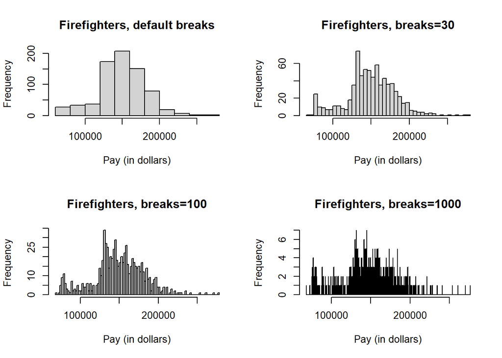

```r
par(mfrow=c(2,2))
hist(salaries2$TotalPay,main="Firefighters, default breaks", xlab="Pay (in dollars)")
hist(salaries2$TotalPay,main="Firefighters, breaks=30", xlab="Pay (in dollars)", breaks=30)
hist(salaries2$TotalPay,main="Firefighters, breaks=100", xlab="Pay (in dollars)", breaks=100)
hist(salaries2$TotalPay,main="Firefighters, breaks=1000", xlab="Pay (in dollars)",breaks=1000)
```

## Wykresy pudełkowe

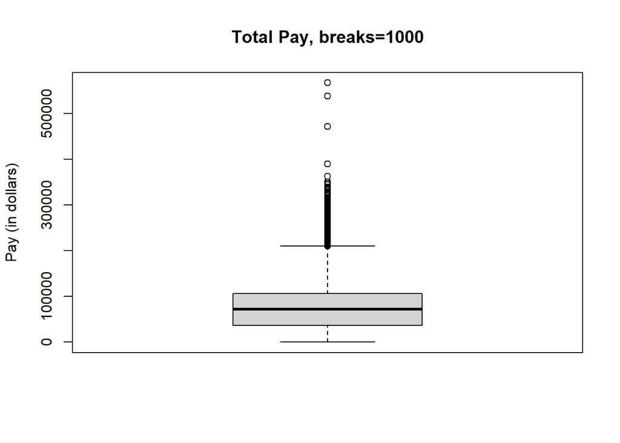

```r
par(mfrow=c(1,1))
boxplot(salaries$TotalPay,main="Total Pay, breaks=1000", ylab="Pay (in dollars)")
```

# Estymacja funkcji gęstości

Pierwszy raport dotyczy nieparametrycznej estymacji gęstości. Klasycznym nieparametrycznym estymatorem gęstości jest histogram, który dostarcza nieciągłe i stałe oszacowania. W tym raporcie skupiono się na niektórych alternatywach, które zapewniają ciągłe lub nawet gładkie oszacowania zamiast.

- jeśli to możliwe, wybierz wektoryzowane implementacje w R,
- jeśli niewielka strata w dokładności jest do zaakceptowania, przybliżone rozwiązanie może być o rzędy wielkości szybsze niż implementacja literalna,
- czas potrzebny do numerycznej oceny różnych [funkcje elementarne](https://en.wikipedia.org/wiki/Elementary_function) może bardzo zależeć od funkcji i sposobu implementacji obliczeń.

Metody kernelowe opierają się na jednym lub więcej *parametrach regularności*, które muszą być dobrane tak, aby osiągnąć właściwą równowagę w dostosowaniu do danych bez zbytniego dostosowywania się do losowej zmienności w danych.

Wybór odpowiedniej ilości regularności jest równie ważny jak wybór metody do użycia w pierwszej kolejności. W rzeczywistości może być ważniejszy. Tak naprawdę nie mamy kompletnej implementacji nieparametrycznego estymatora dopóki nie zaimplementujemy automatycznego, opartego na danych sposobu wyboru ilości regulacji.

Implementacja tylko obliczeń dla oceny estymatora jądra, powiedzmy, i pozostawiając to całkowicie użytkownikowi wyboru szerokości pasma jest pracą w połowie wykonaną. Metody i implementacje do wyboru szerokości pasma są więc w tym raporcie omówione dość szczegółowo.

Aby utworzyć wykres gęstości jądra, musisz oszacować gęstość jądra. W tym celu można użyć funkcji density, a następnie przekazać obiekt density do funkcji plot.

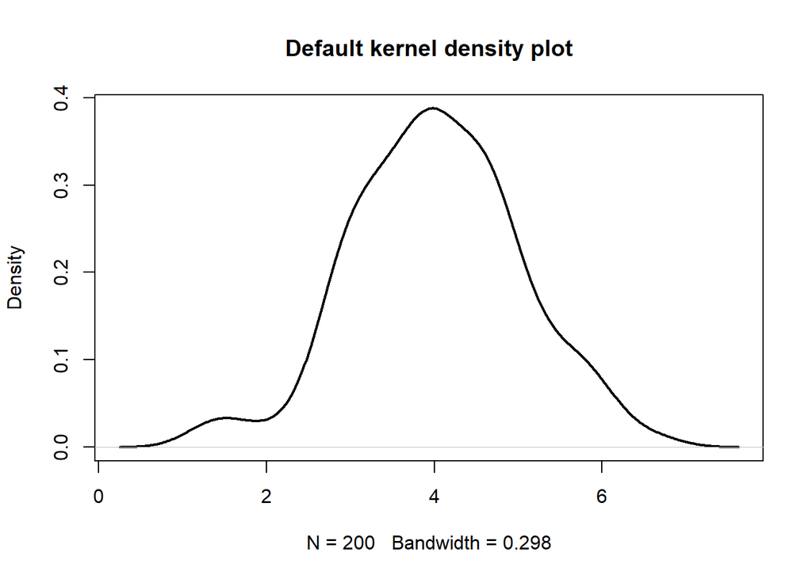

```r
# dane
set.seed(14012021)
data <- rnorm(200, mean = 4)

# Kernel density estimation
d <- density(data)

# Kernel density plot
plot(d, lwd = 2, main = "Default kernel density plot")
```

Argument jądra funkcji gęstości domyślnie używa jądra gaussowskiego (kernel = “gaussian”), ale dostępnych jest więcej typów jądra, takich jak “prostokątne”, “trójkątne”, “epanechnikov”, “biweight”, “cosine” i “optcosine”. Wybór będzie zależał od twoich danych, ale w większości scenariuszy wartość domyślna jest najbardziej zalecana.

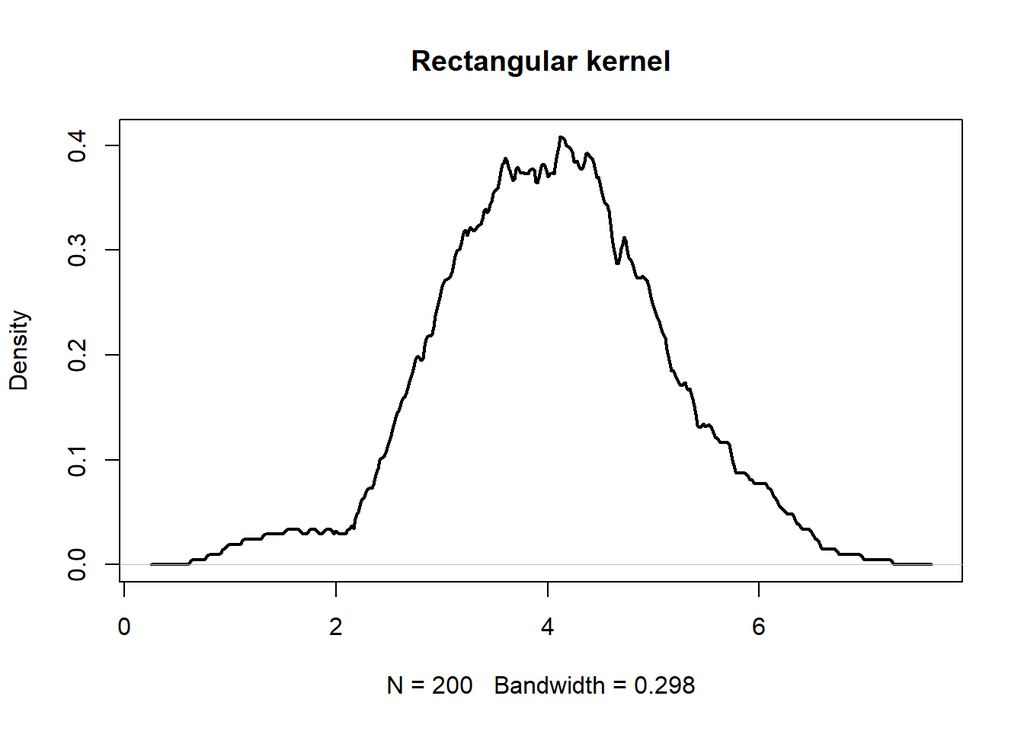

```r
# Data
set.seed(14012021)
data <- rnorm(200, mean = 4)

# Kernel density estimation
d <- density(data,
             kernel = "rectangular")

# Kernel density plot
plot(d, lwd = 2, main = "Rectangular kernel")
```

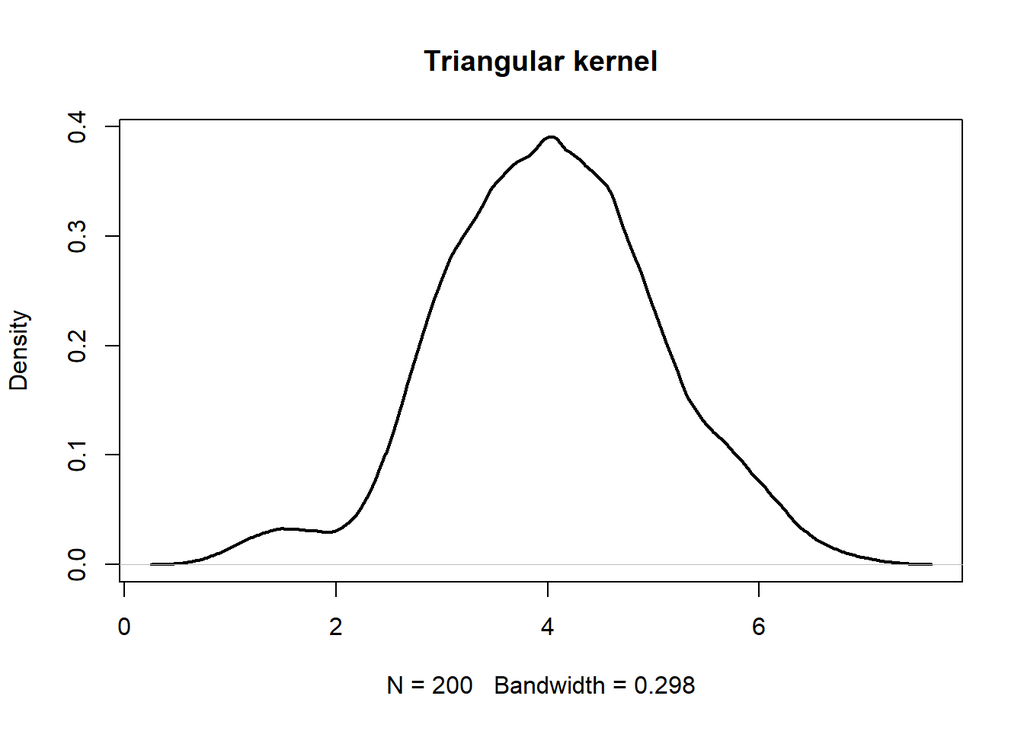

```r
# Data
set.seed(14012021)
data <- rnorm(200, mean = 4)

# Kernel density estimation
d <- density(data,
             kernel = "triangular")

# Kernel density plot
plot(d, lwd = 2, main = "Triangular kernel")
```

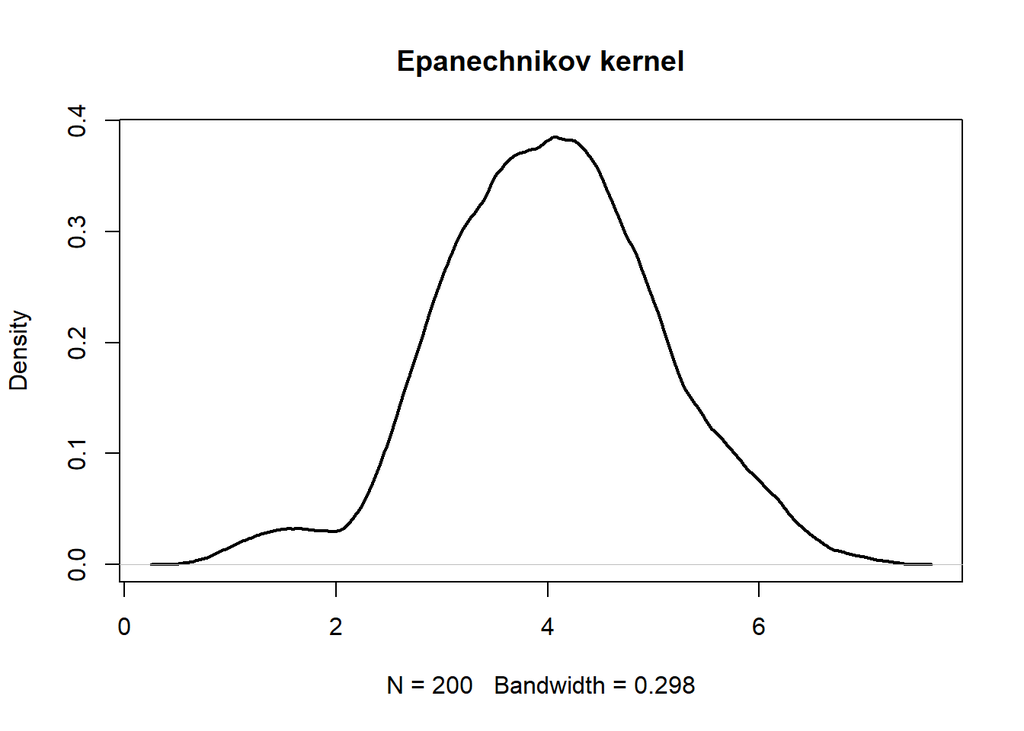

```r
# Data
set.seed(14012021)
data <- rnorm(200, mean = 4)

# Kernel density estimation
d <- density(data,
             kernel = "epanechnikov")

# Kernel density plot
plot(d, lwd = 2, main = "Epanechnikov kernel")
```

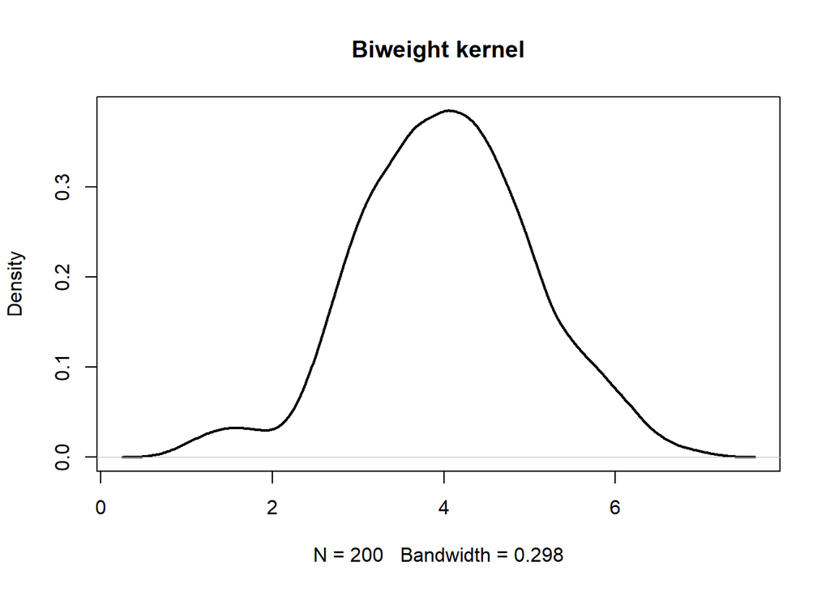

```r
# Data
set.seed(14012021)
data <- rnorm(200, mean = 4)

# Kernel density estimation
d <- density(data,
             kernel = "biweight")

# Kernel density plot
plot(d, lwd = 2, main = "Biweight kernel")
```

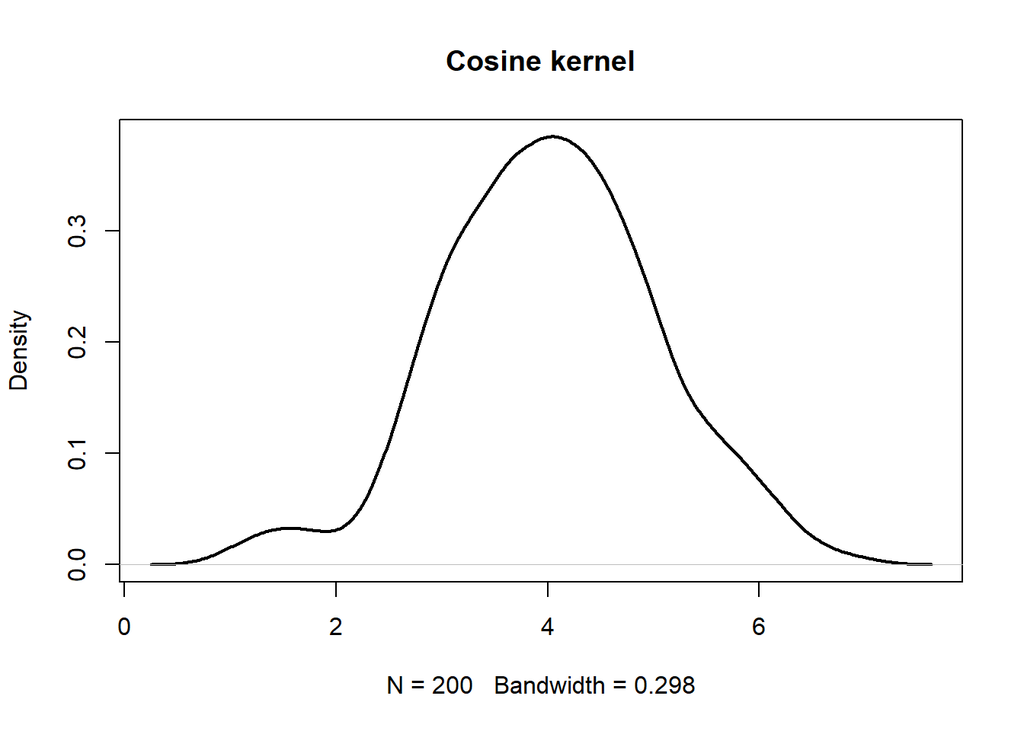

```r
# Data
set.seed(14012021)
data <- rnorm(200, mean = 4)

# Kernel density estimation
d <- density(data,
             kernel = "cosine")

# Kernel density plot
plot(d, lwd = 2, main = "Cosine kernel")
```

## Selekcja pasma

Argument bw funkcji gęstości pozwala na zmianę używanego pasma wygładzania. Możesz przekazać wartość lub ciąg znaków podający regułę wyboru lub funkcję. Domyślną wartością jest “nrd0” (lub bw.nrd0(.)), która implementuje podejście oparte na zasadzie reguły kciuka :-) Inne dostępne opcje to:

### Reguła Scotta (1992)

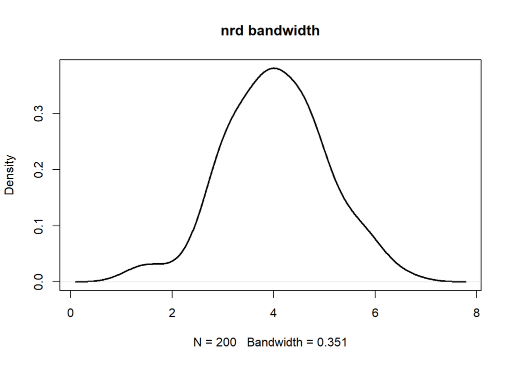

```r
# Data
set.seed(14012021)
data <- rnorm(200, mean = 4)

# Kernel density estimation
d <- density(data,
             bw = "nrd")

# Kernel density plot
plot(d, lwd = 2, main = "nrd bandwidth")
```

### Nieobciążona cross-walidacja

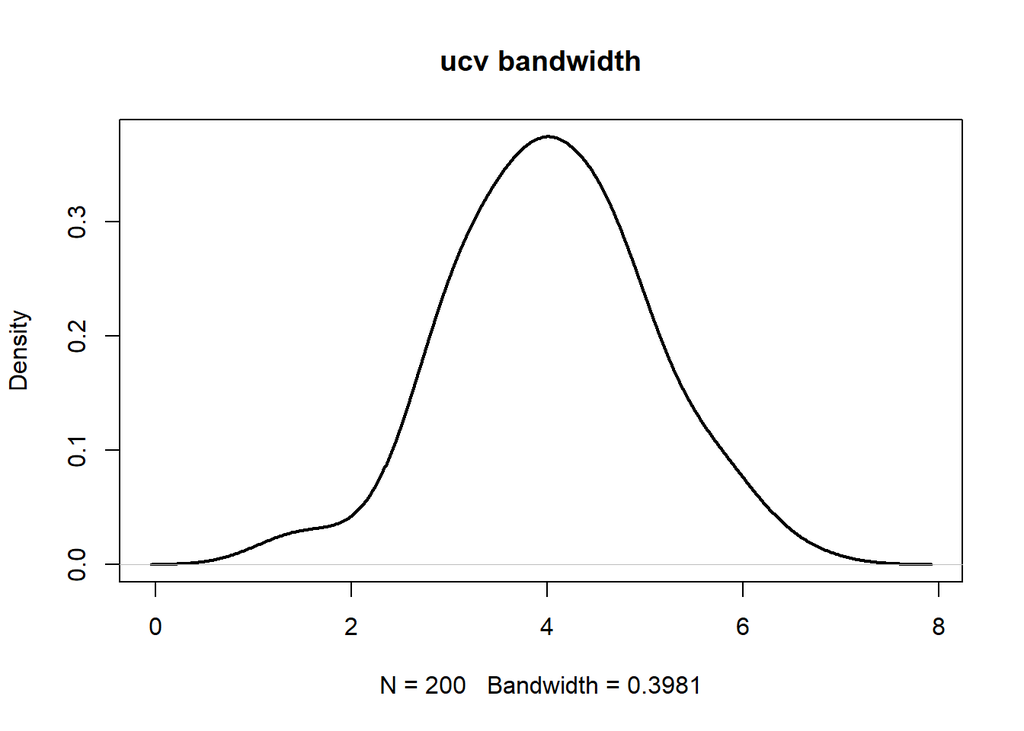

```r
# Data
set.seed(14012021)
data <- rnorm(200, mean = 4)

# Kernel density estimation
d <- density(data,
             bw = "ucv")

# Kernel density plot
plot(d, lwd = 2, main = "ucv bandwidth")
```

### Obciążona cross-walidacja

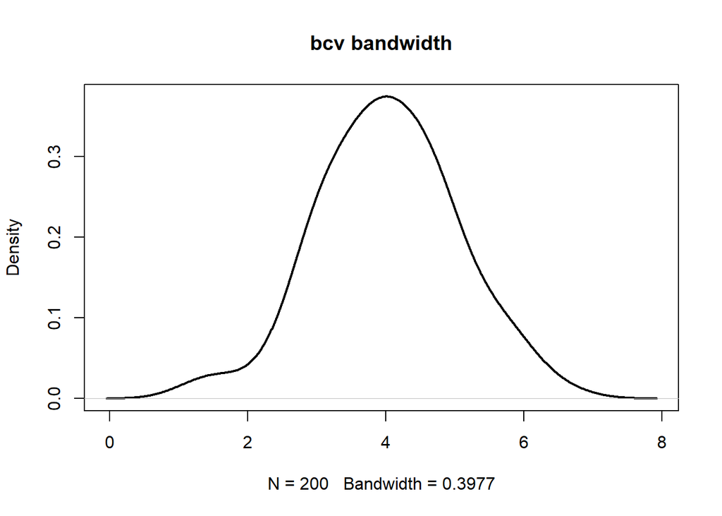

```r
# Data
set.seed(14012021)
data <- rnorm(200, mean = 4)

# Kernel density estimation
d <- density(data,
             bw = "bcv")

# Kernel density plot
plot(d, lwd = 2, main = "bcv bandwidth")
```

### Metoda Sheather & Jones (1991)

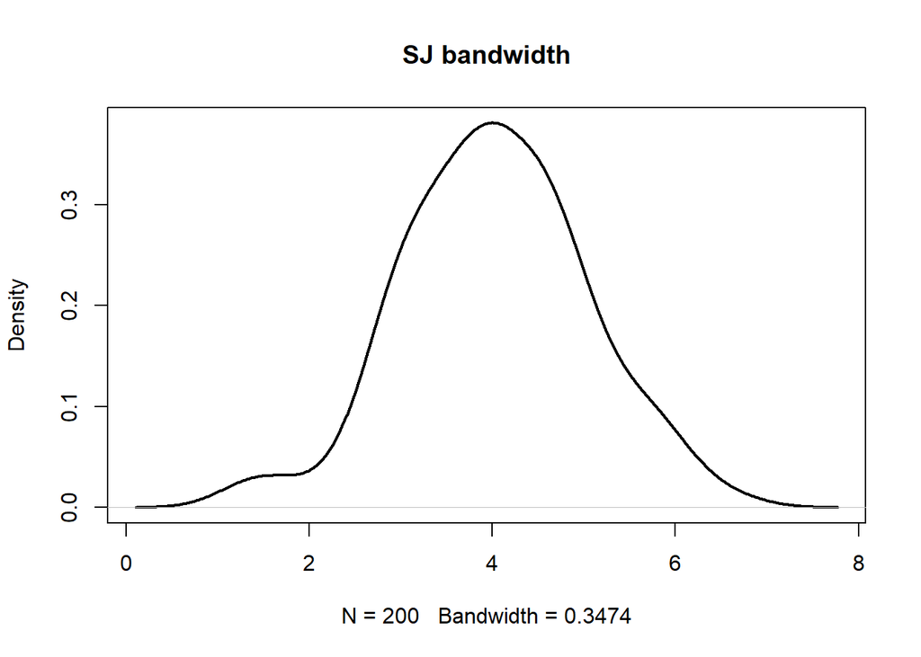

```r
# Data
set.seed(14012021)
data <- rnorm(200, mean = 4)

# Kernel density estimation
d <- density(data,
             bw = "SJ")

# Kernel density plot
plot(d, lwd = 2, main = "SJ bandwidth")
```

**Ostrzeżenie!**

Szerokość pasma musi być bardzo starannie dobrana! Mała szerokość pasma spowoduje powstanie nadmiernie dopasowanej krzywej, natomiast zbyt duża szerokość pasma spowoduje powstanie krzywej nadmiernie wygładzonej.

# Ćwiczenie 1.

Uruchom demo estymatora funkcji gęstości kernel. Zmieniaj zarówno dane wejściowe, jak i opcje estymatora - szerokość pasma oraz rodzaj funkcji jądrowej. Czy widzisz istotne różnice w oszacowaniu?

```r
library(remotes)
library(KDE)
shiny_kde()
```

```
## PhantomJS not found. You can install it with webshot::install_phantomjs(). If it is installed, please make sure the phantomjs executable can be found via the PATH variable.
```

Shiny applications not supported in static R Markdown documents

Demo estymatora funkcji gęstości kernel mamy do wyboru następujące przekształcenia dotyczące:

- funkcji gęstości: zmieniamy kształt i dobieramy wybrane parametry, dostępne przykładowe rozkłady, to:

normalny - krzywa dzwonowata, kształt zależny od średniej i odchylenia standardowego;

beta - jest rozkładem prawdopodobieństwa ciągłym, który opisuje zmienne losowe ograniczone do przedziału [0,1], jest bardzo elastyczny – dzięki manipulacji parametrami𝛼i β można uzyskać różne kształty rozkładu;

wykładniczy - ciągły rozkład prawdopodobieństwa, który modeluje czas oczekiwania między niezależnymi zdarzeniami, które zachodzą z ustaloną średnią częstością, Wzrost parametru `rate` sprawia, że zdarzenia są bardziej prawdopodobne blisko x=0, co oznacza, że czas oczekiwania jest krótki. Wowczas widoczny jest bardziej stromy spadek funkcji gęstości. Mniejsza wartość `rate` oznacza bardziej rozciągnięty rozkład, w którym wyższe wartości stają się bardziej prawdopodobne, więc funkcja gęstości spada wolniej;

jednostajny - rozkład prawdopodobieństwa ciągły (lub dyskretny), w którym każda wartość w określonym przedziale ma takie samo prawdopodobieństwo wystąpienia, a parametry `min` i `max` określają granice tego przedziału.

- jądra funkcji gęstości: pozwala oszacować rozkład prawdopodobieństwa zmiennej losowej na podstawie próby danych. Zamiast przyjmować konkretne założenie co do kształtu rozkładu, wykorzystujemy jądra funkcji gęstości by uzyskać gładką krzywą, która przybliża rozkład próby.

Przykładowe jądra funkcji:

Gaussian - bardzo gładka krzywa dzwonowata o nieskończonym zasięgu;

Epanechnikov - jest ono ograniczone do [−1,1], co oznacza, że obserwacje mają wpływ tylko w bliskim sąsiedztwie x, wykres jest gładki, przypomina odwróconą parabolę

- szerokości pasma- kontrolują poziom wygładzenia estymowanej krzywej rozkładu. Zbyt mała szerokość pasma dokładnie odzorowuje szczegóły, ale wykres wówczas staje się “poszarpany”, gdyż reaguje na przypadkowe odchylenia, czyli tzw. szum. Natomiast zbyt duża szerokość pasm tworzy zbyt gładki wykres. Estymowana gęstość może nie oddawać pełnego obrazu rozkładu danych.

Według sugestii dema najlepsze szerokości pasm dla 3 podstawowych metod jakimi są pco_method, cross_validation i goldenshluger_lepski są 0.22, 0.22 i 0.36. Wykres przy takim doborze szerokości wydaje się dobrze dopasowywać do danych. Przy wartościach 0.15>, wykres natomiast zdaje się być poszarpany, a przy 0.8< płaski.

# Ćwiczenie 2.

Wykorzystując dowolną funkcję R do estymacji funkcji gęstości oszacuj jej przebieg dla wynagrodzeń (zbiór danych salaries) strażaków w San Francisco. Wykorzystaj metody graficzne dostępne w pakiecie ggplot2. Mile widziane przekroje oraz odpowiedzi na pytania badawcze zadane na wstępie.

## 2.1 Estymacja funkcji gęstości i oszacowanie jej przebiegu dla wynagrodzeń strażaków w San Francisco

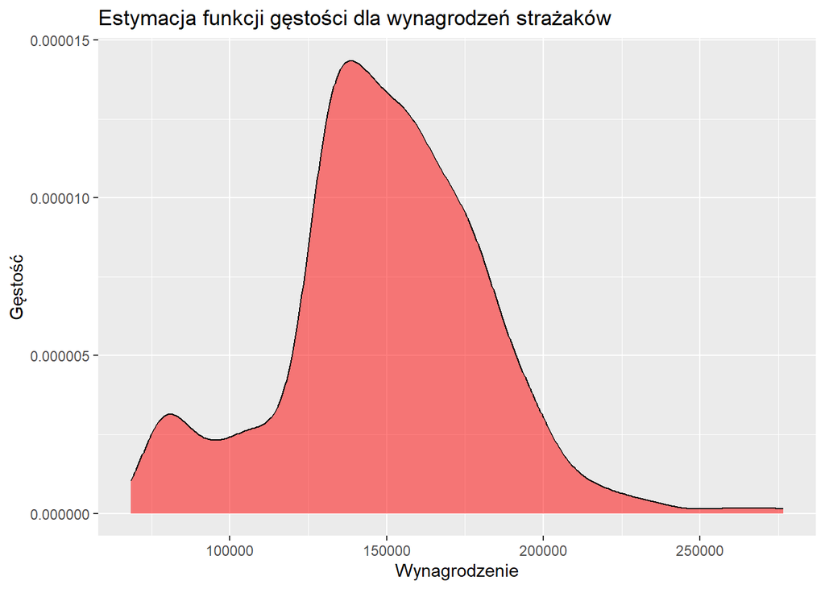

```r
ff <- subset(salaries, JobTitle=="Firefighter" & Status=="FT")
ggplot(ff, aes(x = TotalPay)) +
  geom_density(fill = "red", alpha = 0.5) +
  labs(title = "Estymacja funkcji gęstości dla wynagrodzeń strażaków",
       x = "Wynagrodzenie",
       y = "Gęstość")
```

## 2.3 Jak zmieniały się wynagrodzenia w czasie?

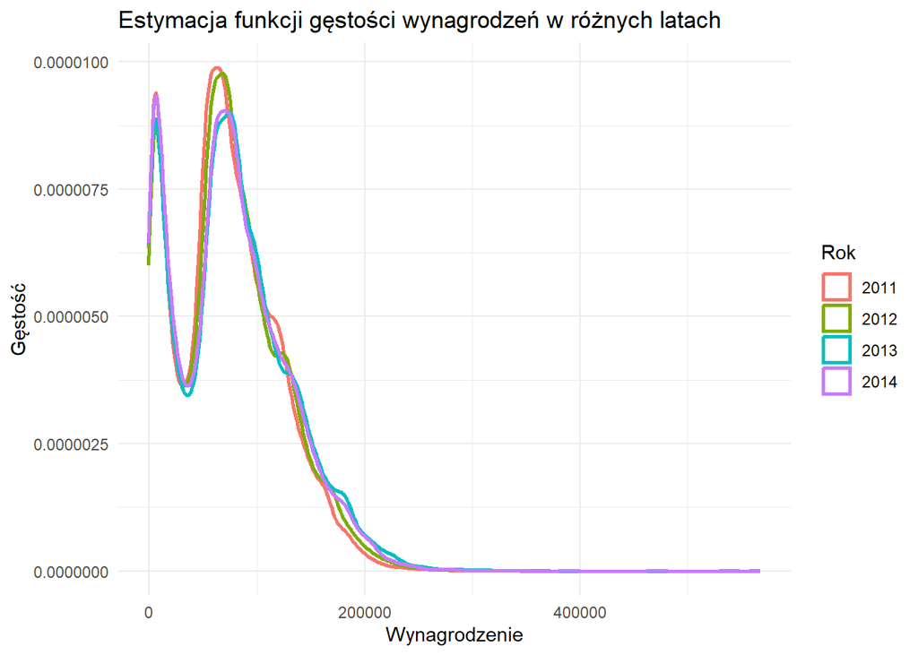

```r
ggplot(salaries, aes(x = TotalPay, color = factor(Year))) +
  geom_density(size = 1) +
  labs(title = "Estymacja funkcji gęstości wynagrodzeń w różnych latach",
       x = "Wynagrodzenie",
       y = "Gęstość",
       color = "Rok") +
  theme_minimal()
```

## 2.2 Jak płaca podstawowa, wynagrodzenie za nadgodziny i świadczenia są rozdzielane pomiędzy różne grupy?

Wybrano 5 najpopularniejszych stanowisk.

```r
top_titles <- salaries %>%
  count(JobTitle) %>%
  arrange(desc(n)) %>%
  top_n(5, n)

print(top_titles)
```

```
##                       JobTitle    n
## 1             Transit Operator 7036
## 2                Special Nurse 4389
## 3             Registered Nurse 3736
## 4 Public Svc Aide-Public Works 2518
## 5             Police Officer 3 2421
```

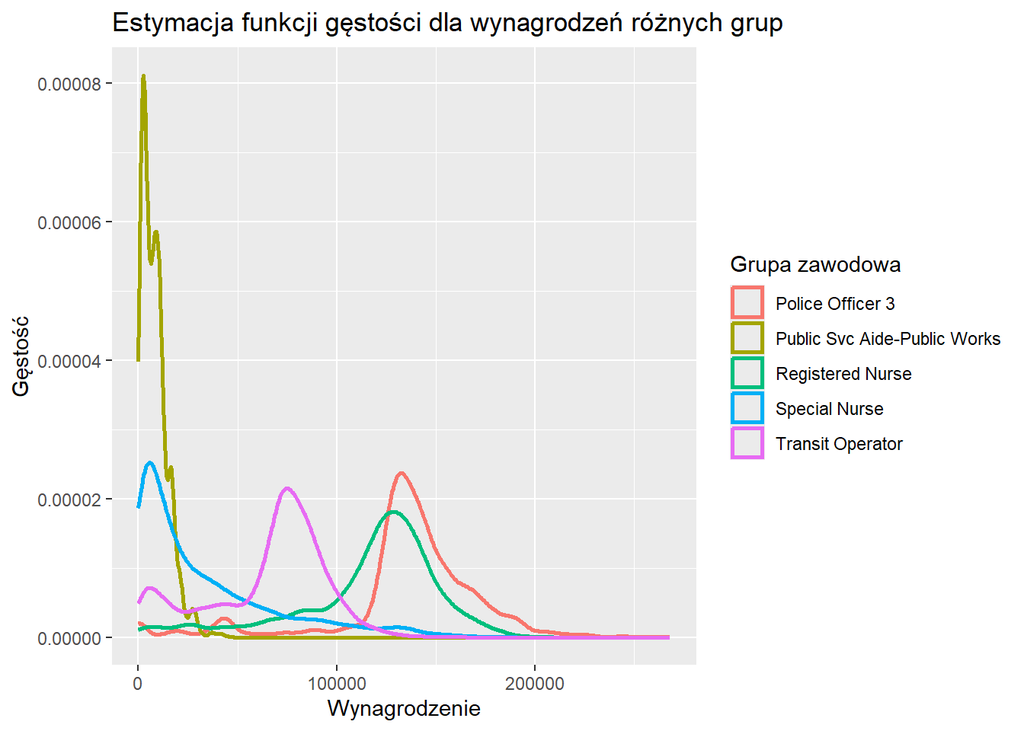

```r
grupy <- salaries %>%
  filter(JobTitle %in% top_titles$JobTitle)

ggplot(grupy, aes(x = TotalPay, color = JobTitle)) +
  geom_density(size = 1) +
  labs(title = "Estymacja funkcji gęstości dla wynagrodzeń różnych grup",
       x = "Wynagrodzenie",
       y = "Gęstość",
       color = "Grupa zawodowa")
```